# Risk Factor Analysis

## Outcome Variable

**Outcome Variable:** ever_stunted

## Predictor Variables

**Intervention Variable:** enstunt

**Adjustment Set:**

- arm
- sex
- W_mage
- meducyrs
- feducyrs
- W_mhtcm
- vagbrth
- brthmon
- W_parity
- delta_W_mage
- delta_meducyrs
- delta_feducyrs
- delta_W_mhtcm
- delta_vagbrth
- delta_brthmon
- delta_W_parity

## Stratifying Variables

The analysis was stratified on these variable(s):

- agecat
- studyid
- country

## Data Summary

| agecat | studyid | country | enstunt | ever_stunted | n_cell | n |
| --- | --- | --- | --- | --- | --- | --- |
| 0-6 months | ki0047075b-MAL-ED | BANGLADESH | 0 | 0 | 210 | 257 |
| 0-6 months | ki0047075b-MAL-ED | BANGLADESH | 0 | 1 | 0 | 257 |
| 0-6 months | ki0047075b-MAL-ED | BANGLADESH | 1 | 0 | 0 | 257 |
| 0-6 months | ki0047075b-MAL-ED | BANGLADESH | 1 | 1 | 47 | 257 |
| 0-6 months | ki0047075b-MAL-ED | BRAZIL | 0 | 0 | 170 | 191 |
| 0-6 months | ki0047075b-MAL-ED | BRAZIL | 0 | 1 | 0 | 191 |
| 0-6 months | ki0047075b-MAL-ED | BRAZIL | 1 | 0 | 0 | 191 |
| 0-6 months | ki0047075b-MAL-ED | BRAZIL | 1 | 1 | 21 | 191 |
| 0-6 months | ki0047075b-MAL-ED | INDIA | 0 | 0 | 173 | 206 |
| 0-6 months | ki0047075b-MAL-ED | INDIA | 0 | 1 | 0 | 206 |
| 0-6 months | ki0047075b-MAL-ED | INDIA | 1 | 0 | 0 | 206 |
| 0-6 months | ki0047075b-MAL-ED | INDIA | 1 | 1 | 33 | 206 |
| 0-6 months | ki0047075b-MAL-ED | NEPAL | 0 | 0 | 155 | 173 |
| 0-6 months | ki0047075b-MAL-ED | NEPAL | 0 | 1 | 0 | 173 |
| 0-6 months | ki0047075b-MAL-ED | NEPAL | 1 | 0 | 0 | 173 |
| 0-6 months | ki0047075b-MAL-ED | NEPAL | 1 | 1 | 18 | 173 |
| 0-6 months | ki0047075b-MAL-ED | PERU | 0 | 0 | 253 | 287 |
| 0-6 months | ki0047075b-MAL-ED | PERU | 0 | 1 | 0 | 287 |
| 0-6 months | ki0047075b-MAL-ED | PERU | 1 | 0 | 0 | 287 |
| 0-6 months | ki0047075b-MAL-ED | PERU | 1 | 1 | 34 | 287 |
| 0-6 months | ki0047075b-MAL-ED | SOUTH AFRICA | 0 | 0 | 234 | 262 |
| 0-6 months | ki0047075b-MAL-ED | SOUTH AFRICA | 0 | 1 | 0 | 262 |
| 0-6 months | ki0047075b-MAL-ED | SOUTH AFRICA | 1 | 0 | 0 | 262 |
| 0-6 months | ki0047075b-MAL-ED | SOUTH AFRICA | 1 | 1 | 28 | 262 |
| 0-6 months | ki0047075b-MAL-ED | TANZANIA, UNITED REPUBLIC OF | 0 | 0 | 105 | 123 |
| 0-6 months | ki0047075b-MAL-ED | TANZANIA, UNITED REPUBLIC OF | 0 | 1 | 0 | 123 |
| 0-6 months | ki0047075b-MAL-ED | TANZANIA, UNITED REPUBLIC OF | 1 | 0 | 0 | 123 |
| 0-6 months | ki0047075b-MAL-ED | TANZANIA, UNITED REPUBLIC OF | 1 | 1 | 18 | 123 |
| 0-6 months | ki1000108-CMC-V-BCS-2002 | INDIA | 0 | 0 | 79 | 97 |
| 0-6 months | ki1000108-CMC-V-BCS-2002 | INDIA | 0 | 1 | 2 | 97 |

[output cut: 352 more lines]

The following strata were considered:

- agecat: 0-24 months, studyid: ki0047075b-MAL-ED, country: BANGLADESH
- agecat: 0-24 months, studyid: ki0047075b-MAL-ED, country: BRAZIL
- agecat: 0-24 months, studyid: ki0047075b-MAL-ED, country: INDIA
- agecat: 0-24 months, studyid: ki0047075b-MAL-ED, country: NEPAL
- agecat: 0-24 months, studyid: ki0047075b-MAL-ED, country: PERU
- agecat: 0-24 months, studyid: ki0047075b-MAL-ED, country: SOUTH AFRICA
- agecat: 0-24 months, studyid: ki0047075b-MAL-ED, country: TANZANIA, UNITED REPUBLIC OF
- agecat: 0-24 months, studyid: ki1000108-CMC-V-BCS-2002, country: INDIA
- agecat: 0-24 months, studyid: ki1000108-IRC, country: INDIA
- agecat: 0-24 months, studyid: ki1000109-EE, country: PAKISTAN
- agecat: 0-24 months, studyid: ki1000109-ResPak, country: PAKISTAN
- agecat: 0-24 months, studyid: ki1000304b-SAS-CompFeed, country: INDIA
- agecat: 0-24 months, studyid: ki1000304b-SAS-FoodSuppl, country: INDIA
- agecat: 0-24 months, studyid: ki1017093-NIH-Birth, country: BANGLADESH
- agecat: 0-24 months, studyid: ki1017093c-NIH-Crypto, country: BANGLADESH
- agecat: 0-24 months, studyid: ki1066203-TanzaniaChild2, country: TANZANIA, UNITED REPUBLIC OF
- agecat: 0-24 months, studyid: ki1101329-Keneba, country: GAMBIA
- agecat: 0-24 months, studyid: ki1112895-Guatemala BSC, country: GUATEMALA
- agecat: 0-24 months, studyid: ki1112895-iLiNS-Zinc, country: BURKINA FASO
- agecat: 0-24 months, studyid: ki1113344-GMS-Nepal, country: NEPAL
- agecat: 0-24 months, studyid: ki1114097-CMIN, country: BANGLADESH
- agecat: 0-24 months, studyid: ki1114097-CMIN, country: BRAZIL
- agecat: 0-24 months, studyid: ki1114097-CMIN, country: GUINEA-BISSAU
- agecat: 0-24 months, studyid: ki1114097-CMIN, country: PERU
- agecat: 0-24 months, studyid: ki1114097-CONTENT, country: PERU
- agecat: 0-24 months, studyid: ki1119695-PROBIT, country: BELARUS
- agecat: 0-24 months, studyid: ki1126311-ZVITAMBO, country: ZIMBABWE
- agecat: 0-24 months, studyid: ki1135781-COHORTS, country: GUATEMALA
- agecat: 0-24 months, studyid: ki1135781-COHORTS, country: INDIA
- agecat: 0-24 months, studyid: ki1135781-COHORTS, country: PHILIPPINES
- agecat: 0-24 months, studyid: ki1148112-LCNI-5, country: MALAWI
- agecat: 0-24 months, studyid: kiGH5241-JiVitA-3, country: BANGLADESH
- agecat: 0-24 months, studyid: kiGH5241-JiVitA-4, country: BANGLADESH
- agecat: 0-6 months, studyid: ki0047075b-MAL-ED, country: BANGLADESH
- agecat: 0-6 months, studyid: ki0047075b-MAL-ED, country: BRAZIL
- agecat: 0-6 months, studyid: ki0047075b-MAL-ED, country: INDIA
- agecat: 0-6 months, studyid: ki0047075b-MAL-ED, country: NEPAL
- agecat: 0-6 months, studyid: ki0047075b-MAL-ED, country: PERU
- agecat: 0-6 months, studyid: ki0047075b-MAL-ED, country: SOUTH AFRICA
- agecat: 0-6 months, studyid: ki0047075b-MAL-ED, country: TANZANIA, UNITED REPUBLIC OF
- agecat: 0-6 months, studyid: ki1000108-CMC-V-BCS-2002, country: INDIA
- agecat: 0-6 months, studyid: ki1000108-IRC, country: INDIA
- agecat: 0-6 months, studyid: ki1000109-EE, country: PAKISTAN
- agecat: 0-6 months, studyid: ki1000109-ResPak, country: PAKISTAN
- agecat: 0-6 months, studyid: ki1000304b-SAS-CompFeed, country: INDIA
- agecat: 0-6 months, studyid: ki1000304b-SAS-FoodSuppl, country: INDIA
- agecat: 0-6 months, studyid: ki1017093-NIH-Birth, country: BANGLADESH
- agecat: 0-6 months, studyid: ki1017093c-NIH-Crypto, country: BANGLADESH
- agecat: 0-6 months, studyid: ki1066203-TanzaniaChild2, country: TANZANIA, UNITED REPUBLIC OF
- agecat: 0-6 months, studyid: ki1101329-Keneba, country: GAMBIA
- agecat: 0-6 months, studyid: ki1112895-Guatemala BSC, country: GUATEMALA
- agecat: 0-6 months, studyid: ki1113344-GMS-Nepal, country: NEPAL
- agecat: 0-6 months, studyid: ki1114097-CMIN, country: BANGLADESH
- agecat: 0-6 months, studyid: ki1114097-CMIN, country: BRAZIL
- agecat: 0-6 months, studyid: ki1114097-CMIN, country: GUINEA-BISSAU
- agecat: 0-6 months, studyid: ki1114097-CMIN, country: PERU
- agecat: 0-6 months, studyid: ki1114097-CONTENT, country: PERU
- agecat: 0-6 months, studyid: ki1119695-PROBIT, country: BELARUS
- agecat: 0-6 months, studyid: ki1126311-ZVITAMBO, country: ZIMBABWE
- agecat: 0-6 months, studyid: ki1135781-COHORTS, country: GUATEMALA
- agecat: 0-6 months, studyid: ki1135781-COHORTS, country: INDIA
- agecat: 0-6 months, studyid: ki1135781-COHORTS, country: PHILIPPINES
- agecat: 0-6 months, studyid: ki1148112-LCNI-5, country: MALAWI
- agecat: 0-6 months, studyid: kiGH5241-JiVitA-3, country: BANGLADESH
- agecat: 0-6 months, studyid: kiGH5241-JiVitA-4, country: BANGLADESH
- agecat: 6-24 months, studyid: ki0047075b-MAL-ED, country: BANGLADESH
- agecat: 6-24 months, studyid: ki0047075b-MAL-ED, country: BRAZIL
- agecat: 6-24 months, studyid: ki0047075b-MAL-ED, country: INDIA
- agecat: 6-24 months, studyid: ki0047075b-MAL-ED, country: NEPAL
- agecat: 6-24 months, studyid: ki0047075b-MAL-ED, country: PERU
- agecat: 6-24 months, studyid: ki0047075b-MAL-ED, country: SOUTH AFRICA
- agecat: 6-24 months, studyid: ki0047075b-MAL-ED, country: TANZANIA, UNITED REPUBLIC OF
- agecat: 6-24 months, studyid: ki1000108-CMC-V-BCS-2002, country: INDIA
- agecat: 6-24 months, studyid: ki1000108-IRC, country: INDIA
- agecat: 6-24 months, studyid: ki1000109-EE, country: PAKISTAN
- agecat: 6-24 months, studyid: ki1000109-ResPak, country: PAKISTAN
- agecat: 6-24 months, studyid: ki1000304b-SAS-CompFeed, country: INDIA
- agecat: 6-24 months, studyid: ki1000304b-SAS-FoodSuppl, country: INDIA
- agecat: 6-24 months, studyid: ki1017093-NIH-Birth, country: BANGLADESH
- agecat: 6-24 months, studyid: ki1017093c-NIH-Crypto, country: BANGLADESH
- agecat: 6-24 months, studyid: ki1066203-TanzaniaChild2, country: TANZANIA, UNITED REPUBLIC OF
- agecat: 6-24 months, studyid: ki1101329-Keneba, country: GAMBIA
- agecat: 6-24 months, studyid: ki1112895-Guatemala BSC, country: GUATEMALA
- agecat: 6-24 months, studyid: ki1112895-iLiNS-Zinc, country: BURKINA FASO
- agecat: 6-24 months, studyid: ki1113344-GMS-Nepal, country: NEPAL
- agecat: 6-24 months, studyid: ki1114097-CMIN, country: BRAZIL
- agecat: 6-24 months, studyid: ki1114097-CMIN, country: GUINEA-BISSAU
- agecat: 6-24 months, studyid: ki1114097-CMIN, country: PERU
- agecat: 6-24 months, studyid: ki1114097-CONTENT, country: PERU
- agecat: 6-24 months, studyid: ki1119695-PROBIT, country: BELARUS
- agecat: 6-24 months, studyid: ki1126311-ZVITAMBO, country: ZIMBABWE
- agecat: 6-24 months, studyid: ki1135781-COHORTS, country: GUATEMALA
- agecat: 6-24 months, studyid: ki1135781-COHORTS, country: INDIA
- agecat: 6-24 months, studyid: ki1135781-COHORTS, country: PHILIPPINES
- agecat: 6-24 months, studyid: ki1148112-LCNI-5, country: MALAWI
- agecat: 6-24 months, studyid: kiGH5241-JiVitA-3, country: BANGLADESH
- agecat: 6-24 months, studyid: kiGH5241-JiVitA-4, country: BANGLADESH

### Dropped Strata

Some strata were dropped due to rare outcomes:

- agecat: 0-6 months, studyid: ki0047075b-MAL-ED, country: BANGLADESH
- agecat: 0-6 months, studyid: ki0047075b-MAL-ED, country: BRAZIL
- agecat: 0-6 months, studyid: ki0047075b-MAL-ED, country: INDIA
- agecat: 0-6 months, studyid: ki0047075b-MAL-ED, country: NEPAL
- agecat: 0-6 months, studyid: ki0047075b-MAL-ED, country: PERU
- agecat: 0-6 months, studyid: ki0047075b-MAL-ED, country: SOUTH AFRICA
- agecat: 0-6 months, studyid: ki0047075b-MAL-ED, country: TANZANIA, UNITED REPUBLIC OF
- agecat: 0-6 months, studyid: ki1000108-CMC-V-BCS-2002, country: INDIA
- agecat: 0-6 months, studyid: ki1000108-IRC, country: INDIA
- agecat: 0-6 months, studyid: ki1000109-EE, country: PAKISTAN
- agecat: 0-6 months, studyid: ki1000109-ResPak, country: PAKISTAN
- agecat: 0-6 months, studyid: ki1000304b-SAS-CompFeed, country: INDIA
- agecat: 0-6 months, studyid: ki1000304b-SAS-FoodSuppl, country: INDIA
- agecat: 0-6 months, studyid: ki1017093-NIH-Birth, country: BANGLADESH
- agecat: 0-6 months, studyid: ki1017093c-NIH-Crypto, country: BANGLADESH
- agecat: 0-6 months, studyid: ki1066203-TanzaniaChild2, country: TANZANIA, UNITED REPUBLIC OF
- agecat: 0-6 months, studyid: ki1101329-Keneba, country: GAMBIA
- agecat: 0-6 months, studyid: ki1112895-Guatemala BSC, country: GUATEMALA
- agecat: 0-6 months, studyid: ki1113344-GMS-Nepal, country: NEPAL
- agecat: 0-6 months, studyid: ki1114097-CMIN, country: BANGLADESH
- agecat: 0-6 months, studyid: ki1114097-CMIN, country: BRAZIL
- agecat: 0-6 months, studyid: ki1114097-CMIN, country: GUINEA-BISSAU
- agecat: 0-6 months, studyid: ki1114097-CMIN, country: PERU
- agecat: 0-6 months, studyid: ki1114097-CONTENT, country: PERU
- agecat: 0-6 months, studyid: ki1119695-PROBIT, country: BELARUS
- agecat: 0-6 months, studyid: ki1126311-ZVITAMBO, country: ZIMBABWE
- agecat: 0-6 months, studyid: ki1135781-COHORTS, country: GUATEMALA
- agecat: 0-6 months, studyid: ki1135781-COHORTS, country: INDIA
- agecat: 0-6 months, studyid: ki1135781-COHORTS, country: PHILIPPINES
- agecat: 0-6 months, studyid: ki1148112-LCNI-5, country: MALAWI
- agecat: 0-6 months, studyid: kiGH5241-JiVitA-3, country: BANGLADESH
- agecat: 0-6 months, studyid: kiGH5241-JiVitA-4, country: BANGLADESH
- agecat: 6-24 months, studyid: ki0047075b-MAL-ED, country: BRAZIL
- agecat: 6-24 months, studyid: ki0047075b-MAL-ED, country: NEPAL
- agecat: 6-24 months, studyid: ki0047075b-MAL-ED, country: TANZANIA, UNITED REPUBLIC OF
- agecat: 6-24 months, studyid: ki1000108-CMC-V-BCS-2002, country: INDIA
- agecat: 6-24 months, studyid: ki1000109-EE, country: PAKISTAN
- agecat: 6-24 months, studyid: ki1000109-ResPak, country: PAKISTAN
- agecat: 6-24 months, studyid: ki1000304b-SAS-FoodSuppl, country: INDIA
- agecat: 6-24 months, studyid: ki1017093c-NIH-Crypto, country: BANGLADESH
- agecat: 6-24 months, studyid: ki1066203-TanzaniaChild2, country: TANZANIA, UNITED REPUBLIC OF
- agecat: 6-24 months, studyid: ki1112895-Guatemala BSC, country: GUATEMALA
- agecat: 6-24 months, studyid: ki1113344-GMS-Nepal, country: NEPAL
- agecat: 6-24 months, studyid: ki1114097-CMIN, country: BRAZIL
- agecat: 6-24 months, studyid: ki1114097-CMIN, country: PERU
- agecat: 6-24 months, studyid: ki1114097-CONTENT, country: PERU
- agecat: 6-24 months, studyid: ki1119695-PROBIT, country: BELARUS
- agecat: 0-24 months, studyid: ki0047075b-MAL-ED, country: BANGLADESH
- agecat: 0-24 months, studyid: ki0047075b-MAL-ED, country: BRAZIL
- agecat: 0-24 months, studyid: ki0047075b-MAL-ED, country: INDIA
- agecat: 0-24 months, studyid: ki0047075b-MAL-ED, country: NEPAL
- agecat: 0-24 months, studyid: ki0047075b-MAL-ED, country: PERU
- agecat: 0-24 months, studyid: ki0047075b-MAL-ED, country: SOUTH AFRICA
- agecat: 0-24 months, studyid: ki0047075b-MAL-ED, country: TANZANIA, UNITED REPUBLIC OF
- agecat: 0-24 months, studyid: ki1000108-CMC-V-BCS-2002, country: INDIA
- agecat: 0-24 months, studyid: ki1000108-IRC, country: INDIA
- agecat: 0-24 months, studyid: ki1000109-EE, country: PAKISTAN
- agecat: 0-24 months, studyid: ki1000109-ResPak, country: PAKISTAN
- agecat: 0-24 months, studyid: ki1000304b-SAS-CompFeed, country: INDIA
- agecat: 0-24 months, studyid: ki1000304b-SAS-FoodSuppl, country: INDIA
- agecat: 0-24 months, studyid: ki1017093-NIH-Birth, country: BANGLADESH
- agecat: 0-24 months, studyid: ki1017093c-NIH-Crypto, country: BANGLADESH
- agecat: 0-24 months, studyid: ki1066203-TanzaniaChild2, country: TANZANIA, UNITED REPUBLIC OF
- agecat: 0-24 months, studyid: ki1112895-Guatemala BSC, country: GUATEMALA
- agecat: 0-24 months, studyid: ki1112895-iLiNS-Zinc, country: BURKINA FASO
- agecat: 0-24 months, studyid: ki1113344-GMS-Nepal, country: NEPAL
- agecat: 0-24 months, studyid: ki1114097-CMIN, country: BANGLADESH
- agecat: 0-24 months, studyid: ki1114097-CMIN, country: BRAZIL
- agecat: 0-24 months, studyid: ki1114097-CMIN, country: GUINEA-BISSAU
- agecat: 0-24 months, studyid: ki1114097-CMIN, country: PERU
- agecat: 0-24 months, studyid: ki1114097-CONTENT, country: PERU
- agecat: 0-24 months, studyid: ki1119695-PROBIT, country: BELARUS
- agecat: 0-24 months, studyid: ki1135781-COHORTS, country: GUATEMALA
- agecat: 0-24 months, studyid: ki1135781-COHORTS, country: INDIA
- agecat: 0-24 months, studyid: ki1135781-COHORTS, country: PHILIPPINES
- agecat: 0-24 months, studyid: ki1148112-LCNI-5, country: MALAWI
- agecat: 0-24 months, studyid: kiGH5241-JiVitA-3, country: BANGLADESH
- agecat: 0-24 months, studyid: kiGH5241-JiVitA-4, country: BANGLADESH

## Methods Detail

We’re interested in the causal parameters $E[Y_a]$ for all values of $a \in \mathcal{A}$. These parameters represent the mean outcome if, possibly contrary to fact, we intervened to set all units to have $A=a$. Under the randomization and positivity assumptions, these are identified by the statistical parameters $\psi_a=E_W[E_{Y|A,W}(Y|A=a,W)]$. In addition, we’re interested in the mean of $Y$, $E[Y]$ under no intervention (the observed mean). We will estimate these parameters by using SuperLearner to fit the relevant likelihood factors – $E_{Y|A,W}(Y|A=a,W)$ and $p(A=a|W)$, and then updating our likelihood fit using a joint TMLE.

For unadjusted analyses ($W=\{\}$), initial likelihoods were estimated using Lrnr_glm to estimate the simple $E(Y|A)$ and Lrnr_mean to estimate $p(A)$. For adjusted analyses, a small library containing Lrnr_glmnet, Lrnr_xgboost, and Lrnr_mean was used.

Having estimated these parameters, we will then use the delta method to estimate relative risks and attributable risks relative to a prespecified baseline level of $A$.

```
##        ever_stunted
## enstunt    0
##       0 5207
##       1  324
```

# Results Detail

## Results Plots

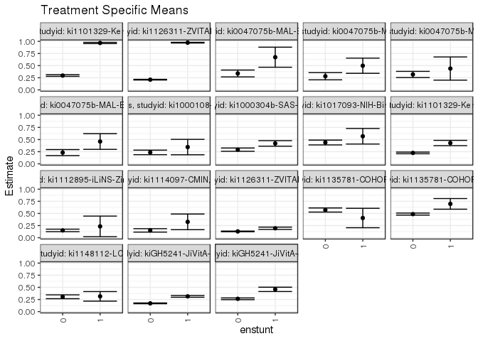

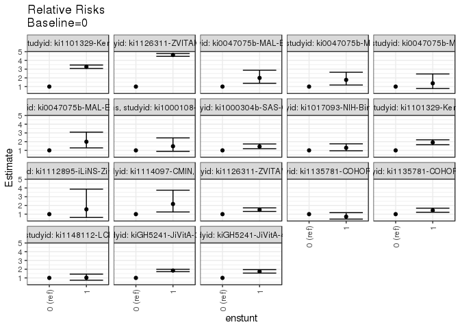

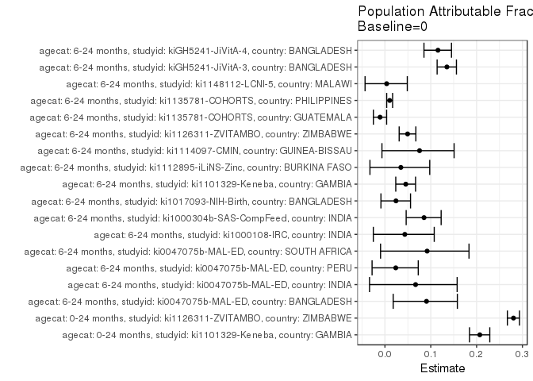

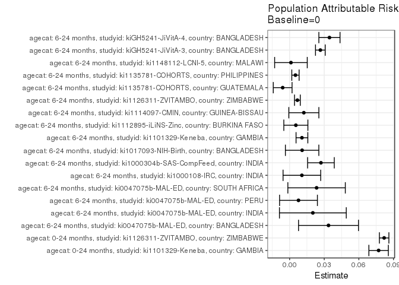

## Results Table

### Parameter: TSM

| agecat | studyid | country | intervention_level | baseline_level | estimate | ci_lower | ci_upper |
| --- | --- | --- | --- | --- | --- | --- | --- |
| 0-24 months | ki1101329-Keneba | GAMBIA | 0 | NA | 0.2955496 | 0.2782209 | 0.3128784 |
| 0-24 months | ki1101329-Keneba | GAMBIA | 1 | NA | 0.9668213 | 0.9543021 | 0.9793405 |
| 0-24 months | ki1126311-ZVITAMBO | ZIMBABWE | 0 | NA | 0.2101651 | 0.2030296 | 0.2173006 |
| 0-24 months | ki1126311-ZVITAMBO | ZIMBABWE | 1 | NA | 0.9724996 | 0.9651036 | 0.9798956 |
| 6-24 months | ki0047075b-MAL-ED | BANGLADESH | 0 | NA | 0.3380189 | 0.2674615 | 0.4085764 |
| 6-24 months | ki0047075b-MAL-ED | BANGLADESH | 1 | NA | 0.6732680 | 0.4666354 | 0.8799006 |
| 6-24 months | ki0047075b-MAL-ED | INDIA | 0 | NA | 0.2811445 | 0.2068108 | 0.3554782 |
| 6-24 months | ki0047075b-MAL-ED | INDIA | 1 | NA | 0.4976205 | 0.3413048 | 0.6539361 |
| 6-24 months | ki0047075b-MAL-ED | PERU | 0 | NA | 0.3180003 | 0.2541521 | 0.3818485 |
| 6-24 months | ki0047075b-MAL-ED | PERU | 1 | NA | 0.4391116 | 0.2000746 | 0.6781485 |
| 6-24 months | ki0047075b-MAL-ED | SOUTH AFRICA | 0 | NA | 0.2305975 | 0.1681293 | 0.2930657 |
| 6-24 months | ki0047075b-MAL-ED | SOUTH AFRICA | 1 | NA | 0.4592384 | 0.2974679 | 0.6210089 |
| 6-24 months | ki1000108-IRC | INDIA | 0 | NA | 0.2342154 | 0.1869568 | 0.2814741 |
| 6-24 months | ki1000108-IRC | INDIA | 1 | NA | 0.3445028 | 0.1857711 | 0.5032346 |
| 6-24 months | ki1000304b-SAS-CompFeed | INDIA | 0 | NA | 0.2912675 | 0.2572732 | 0.3252618 |
| 6-24 months | ki1000304b-SAS-CompFeed | INDIA | 1 | NA | 0.4193275 | 0.3618167 | 0.4768383 |
| 6-24 months | ki1017093-NIH-Birth | BANGLADESH | 0 | NA | 0.4386938 | 0.3890018 | 0.4883858 |
| 6-24 months | ki1017093-NIH-Birth | BANGLADESH | 1 | NA | 0.5672399 | 0.4067114 | 0.7277683 |
| 6-24 months | ki1101329-Keneba | GAMBIA | 0 | NA | 0.2241743 | 0.2069750 | 0.2413736 |
| 6-24 months | ki1101329-Keneba | GAMBIA | 1 | NA | 0.4280452 | 0.3734855 | 0.4826049 |
| 6-24 months | ki1112895-iLiNS-Zinc | BURKINA FASO | 0 | NA | 0.1501976 | 0.1243839 | 0.1760112 |
| 6-24 months | ki1112895-iLiNS-Zinc | BURKINA FASO | 1 | NA | 0.2331079 | 0.0210874 | 0.4451284 |
| 6-24 months | ki1114097-CMIN | GUINEA-BISSAU | 0 | NA | 0.1508466 | 0.1156449 | 0.1860483 |
| 6-24 months | ki1114097-CMIN | GUINEA-BISSAU | 1 | NA | 0.3265370 | 0.1651577 | 0.4879163 |
| 6-24 months | ki1126311-ZVITAMBO | ZIMBABWE | 0 | NA | 0.1295752 | 0.1224250 | 0.1367254 |
| 6-24 months | ki1126311-ZVITAMBO | ZIMBABWE | 1 | NA | 0.1942704 | 0.1701764 | 0.2183644 |
| 6-24 months | ki1135781-COHORTS | GUATEMALA | 0 | NA | 0.5703587 | 0.5280131 | 0.6127042 |
| 6-24 months | ki1135781-COHORTS | GUATEMALA | 1 | NA | 0.4058967 | 0.2057135 | 0.6060799 |
| 6-24 months | ki1135781-COHORTS | PHILIPPINES | 0 | NA | 0.4863803 | 0.4653268 | 0.5074338 |
| 6-24 months | ki1135781-COHORTS | PHILIPPINES | 1 | NA | 0.6969088 | 0.5872991 | 0.8065185 |
| 6-24 months | ki1148112-LCNI-5 | MALAWI | 0 | NA | 0.3057434 | 0.2658639 | 0.3456229 |
| 6-24 months | ki1148112-LCNI-5 | MALAWI | 1 | NA | 0.3145088 | 0.2162641 | 0.4127535 |
| 6-24 months | kiGH5241-JiVitA-3 | BANGLADESH | 0 | NA | 0.1703837 | 0.1620346 | 0.1787329 |
| 6-24 months | kiGH5241-JiVitA-3 | BANGLADESH | 1 | NA | 0.3143780 | 0.2959511 | 0.3328049 |
| 6-24 months | kiGH5241-JiVitA-4 | BANGLADESH | 0 | NA | 0.2637834 | 0.2461871 | 0.2813797 |
| 6-24 months | kiGH5241-JiVitA-4 | BANGLADESH | 1 | NA | 0.4585205 | 0.4140110 | 0.5030299 |

### Parameter: E(Y)

| agecat | studyid | country | intervention_level | baseline_level | estimate | ci_lower | ci_upper |
| --- | --- | --- | --- | --- | --- | --- | --- |
| 0-24 months | ki1101329-Keneba | GAMBIA | NA | NA | 0.3726836 | 0.3551249 | 0.3902423 |
| 0-24 months | ki1126311-ZVITAMBO | ZIMBABWE | NA | NA | 0.2920888 | 0.2845338 | 0.2996439 |
| 6-24 months | ki0047075b-MAL-ED | BANGLADESH | NA | NA | 0.3717277 | 0.3030118 | 0.4404437 |
| 6-24 months | ki0047075b-MAL-ED | INDIA | NA | NA | 0.3012821 | 0.2290517 | 0.3735124 |
| 6-24 months | ki0047075b-MAL-ED | PERU | NA | NA | 0.3256881 | 0.2633362 | 0.3880400 |
| 6-24 months | ki0047075b-MAL-ED | SOUTH AFRICA | NA | NA | 0.2539683 | 0.1917472 | 0.3161893 |
| 6-24 months | ki1000108-IRC | INDIA | NA | NA | 0.2448378 | 0.1989973 | 0.2906782 |
| 6-24 months | ki1000304b-SAS-CompFeed | INDIA | NA | NA | 0.3184183 | 0.2877921 | 0.3490446 |
| 6-24 months | ki1017093-NIH-Birth | BANGLADESH | NA | NA | 0.4495192 | 0.4016596 | 0.4973789 |
| 6-24 months | ki1101329-Keneba | GAMBIA | NA | NA | 0.2348485 | 0.2178001 | 0.2518969 |
| 6-24 months | ki1112895-iLiNS-Zinc | BURKINA FASO | NA | NA | 0.1555985 | 0.1280985 | 0.1830984 |
| 6-24 months | ki1114097-CMIN | GUINEA-BISSAU | NA | NA | 0.1631702 | 0.1281623 | 0.1981780 |
| 6-24 months | ki1126311-ZVITAMBO | ZIMBABWE | NA | NA | 0.1363093 | 0.1293004 | 0.1433183 |
| 6-24 months | ki1135781-COHORTS | GUATEMALA | NA | NA | 0.5643382 | 0.5226328 | 0.6060437 |
| 6-24 months | ki1135781-COHORTS | PHILIPPINES | NA | NA | 0.4914337 | 0.4706238 | 0.5122437 |
| 6-24 months | ki1148112-LCNI-5 | MALAWI | NA | NA | 0.3068966 | 0.2693298 | 0.3444633 |
| 6-24 months | kiGH5241-JiVitA-3 | BANGLADESH | NA | NA | 0.1970206 | 0.1889921 | 0.2050492 |
| 6-24 months | kiGH5241-JiVitA-4 | BANGLADESH | NA | NA | 0.2982933 | 0.2811623 | 0.3154244 |

### Parameter: RR

| agecat | studyid | country | intervention_level | baseline_level | estimate | ci_lower | ci_upper |
| --- | --- | --- | --- | --- | --- | --- | --- |
| 0-24 months | ki1101329-Keneba | GAMBIA | 0 | 0 | 1.0000000 | 1.0000000 | 1.000000 |
| 0-24 months | ki1101329-Keneba | GAMBIA | 1 | 0 | 3.2712656 | 3.0813710 | 3.472863 |
| 0-24 months | ki1126311-ZVITAMBO | ZIMBABWE | 0 | 0 | 1.0000000 | 1.0000000 | 1.000000 |
| 0-24 months | ki1126311-ZVITAMBO | ZIMBABWE | 1 | 0 | 4.6273127 | 4.4690240 | 4.791208 |
| 6-24 months | ki0047075b-MAL-ED | BANGLADESH | 0 | 0 | 1.0000000 | 1.0000000 | 1.000000 |
| 6-24 months | ki0047075b-MAL-ED | BANGLADESH | 1 | 0 | 1.9918055 | 1.3784015 | 2.878181 |
| 6-24 months | ki0047075b-MAL-ED | INDIA | 0 | 0 | 1.0000000 | 1.0000000 | 1.000000 |
| 6-24 months | ki0047075b-MAL-ED | INDIA | 1 | 0 | 1.7699811 | 1.1833635 | 2.647397 |
| 6-24 months | ki0047075b-MAL-ED | PERU | 0 | 0 | 1.0000000 | 1.0000000 | 1.000000 |
| 6-24 months | ki0047075b-MAL-ED | PERU | 1 | 0 | 1.3808528 | 0.7780778 | 2.450596 |
| 6-24 months | ki0047075b-MAL-ED | SOUTH AFRICA | 0 | 0 | 1.0000000 | 1.0000000 | 1.000000 |
| 6-24 months | ki0047075b-MAL-ED | SOUTH AFRICA | 1 | 0 | 1.9915150 | 1.2839393 | 3.089034 |
| 6-24 months | ki1000108-IRC | INDIA | 0 | 0 | 1.0000000 | 1.0000000 | 1.000000 |
| 6-24 months | ki1000108-IRC | INDIA | 1 | 0 | 1.4708802 | 0.8902298 | 2.430258 |
| 6-24 months | ki1000304b-SAS-CompFeed | INDIA | 0 | 0 | 1.0000000 | 1.0000000 | 1.000000 |
| 6-24 months | ki1000304b-SAS-CompFeed | INDIA | 1 | 0 | 1.4396646 | 1.1944701 | 1.735191 |
| 6-24 months | ki1017093-NIH-Birth | BANGLADESH | 0 | 0 | 1.0000000 | 1.0000000 | 1.000000 |
| 6-24 months | ki1017093-NIH-Birth | BANGLADESH | 1 | 0 | 1.2930200 | 0.9548696 | 1.750921 |
| 6-24 months | ki1101329-Keneba | GAMBIA | 0 | 0 | 1.0000000 | 1.0000000 | 1.000000 |
| 6-24 months | ki1101329-Keneba | GAMBIA | 1 | 0 | 1.9094307 | 1.6483697 | 2.211837 |
| 6-24 months | ki1112895-iLiNS-Zinc | BURKINA FASO | 0 | 0 | 1.0000000 | 1.0000000 | 1.000000 |
| 6-24 months | ki1112895-iLiNS-Zinc | BURKINA FASO | 1 | 0 | 1.5520086 | 0.6231370 | 3.865491 |
| 6-24 months | ki1114097-CMIN | GUINEA-BISSAU | 0 | 0 | 1.0000000 | 1.0000000 | 1.000000 |
| 6-24 months | ki1114097-CMIN | GUINEA-BISSAU | 1 | 0 | 2.1646955 | 1.2517050 | 3.743619 |
| 6-24 months | ki1126311-ZVITAMBO | ZIMBABWE | 0 | 0 | 1.0000000 | 1.0000000 | 1.000000 |
| 6-24 months | ki1126311-ZVITAMBO | ZIMBABWE | 1 | 0 | 1.4992873 | 1.3093862 | 1.716730 |
| 6-24 months | ki1135781-COHORTS | GUATEMALA | 0 | 0 | 1.0000000 | 1.0000000 | 1.000000 |
| 6-24 months | ki1135781-COHORTS | GUATEMALA | 1 | 0 | 0.7116517 | 0.4326558 | 1.170556 |
| 6-24 months | ki1135781-COHORTS | PHILIPPINES | 0 | 0 | 1.0000000 | 1.0000000 | 1.000000 |
| 6-24 months | ki1135781-COHORTS | PHILIPPINES | 1 | 0 | 1.4328475 | 1.2178713 | 1.685771 |
| 6-24 months | ki1148112-LCNI-5 | MALAWI | 0 | 0 | 1.0000000 | 1.0000000 | 1.000000 |
| 6-24 months | ki1148112-LCNI-5 | MALAWI | 1 | 0 | 1.0286690 | 0.7371827 | 1.435411 |
| 6-24 months | kiGH5241-JiVitA-3 | BANGLADESH | 0 | 0 | 1.0000000 | 1.0000000 | 1.000000 |
| 6-24 months | kiGH5241-JiVitA-3 | BANGLADESH | 1 | 0 | 1.8451176 | 1.7133854 | 1.986978 |
| 6-24 months | kiGH5241-JiVitA-4 | BANGLADESH | 0 | 0 | 1.0000000 | 1.0000000 | 1.000000 |
| 6-24 months | kiGH5241-JiVitA-4 | BANGLADESH | 1 | 0 | 1.7382461 | 1.5509751 | 1.948129 |

### Parameter: PAR

| agecat | studyid | country | intervention_level | baseline_level | estimate | ci_lower | ci_upper |
| --- | --- | --- | --- | --- | --- | --- | --- |
| 0-24 months | ki1101329-Keneba | GAMBIA | 0 | NA | 0.0771340 | 0.0687012 | 0.0855668 |
| 0-24 months | ki1126311-ZVITAMBO | ZIMBABWE | 0 | NA | 0.0819237 | 0.0778170 | 0.0860304 |
| 6-24 months | ki0047075b-MAL-ED | BANGLADESH | 0 | NA | 0.0337088 | 0.0077240 | 0.0596936 |
| 6-24 months | ki0047075b-MAL-ED | INDIA | 0 | NA | 0.0201375 | -0.0088253 | 0.0491003 |
| 6-24 months | ki0047075b-MAL-ED | PERU | 0 | NA | 0.0076878 | -0.0087063 | 0.0240819 |
| 6-24 months | ki0047075b-MAL-ED | SOUTH AFRICA | 0 | NA | 0.0233708 | -0.0015251 | 0.0482666 |
| 6-24 months | ki1000108-IRC | INDIA | 0 | NA | 0.0106223 | -0.0056948 | 0.0269394 |
| 6-24 months | ki1000304b-SAS-CompFeed | INDIA | 0 | NA | 0.0271508 | 0.0155973 | 0.0387044 |
| 6-24 months | ki1017093-NIH-Birth | BANGLADESH | 0 | NA | 0.0108254 | -0.0036601 | 0.0253110 |
| 6-24 months | ki1101329-Keneba | GAMBIA | 0 | NA | 0.0106742 | 0.0055681 | 0.0157803 |
| 6-24 months | ki1112895-iLiNS-Zinc | BURKINA FASO | 0 | NA | 0.0054009 | -0.0050329 | 0.0158346 |
| 6-24 months | ki1114097-CMIN | GUINEA-BISSAU | 0 | NA | 0.0123235 | -0.0006893 | 0.0253364 |
| 6-24 months | ki1126311-ZVITAMBO | ZIMBABWE | 0 | NA | 0.0067341 | 0.0042350 | 0.0092332 |
| 6-24 months | ki1135781-COHORTS | GUATEMALA | 0 | NA | -0.0060204 | -0.0141577 | 0.0021169 |
| 6-24 months | ki1135781-COHORTS | PHILIPPINES | 0 | NA | 0.0050534 | 0.0018866 | 0.0082203 |
| 6-24 months | ki1148112-LCNI-5 | MALAWI | 0 | NA | 0.0011531 | -0.0129833 | 0.0152895 |
| 6-24 months | kiGH5241-JiVitA-3 | BANGLADESH | 0 | NA | 0.0266369 | 0.0224250 | 0.0308488 |
| 6-24 months | kiGH5241-JiVitA-4 | BANGLADESH | 0 | NA | 0.0345100 | 0.0253373 | 0.0436826 |

### Parameter: PAF

| agecat | studyid | country | intervention_level | baseline_level | estimate | ci_lower | ci_upper |
| --- | --- | --- | --- | --- | --- | --- | --- |
| 0-24 months | ki1101329-Keneba | GAMBIA | 0 | NA | 0.2069691 | 0.1845408 | 0.2287804 |
| 0-24 months | ki1126311-ZVITAMBO | ZIMBABWE | 0 | NA | 0.2804754 | 0.2671396 | 0.2935685 |
| 6-24 months | ki0047075b-MAL-ED | BANGLADESH | 0 | NA | 0.0906814 | 0.0179737 | 0.1580060 |
| 6-24 months | ki0047075b-MAL-ED | INDIA | 0 | NA | 0.0668395 | -0.0336439 | 0.1575546 |
| 6-24 months | ki0047075b-MAL-ED | PERU | 0 | NA | 0.0236047 | -0.0280798 | 0.0726909 |
| 6-24 months | ki0047075b-MAL-ED | SOUTH AFRICA | 0 | NA | 0.0920224 | -0.0095907 | 0.1834083 |
| 6-24 months | ki1000108-IRC | INDIA | 0 | NA | 0.0433852 | -0.0253846 | 0.1075428 |
| 6-24 months | ki1000304b-SAS-CompFeed | INDIA | 0 | NA | 0.0852678 | 0.0463225 | 0.1226226 |
| 6-24 months | ki1017093-NIH-Birth | BANGLADESH | 0 | NA | 0.0240823 | -0.0087262 | 0.0558236 |
| 6-24 months | ki1101329-Keneba | GAMBIA | 0 | NA | 0.0454515 | 0.0236095 | 0.0668048 |
| 6-24 months | ki1112895-iLiNS-Zinc | BURKINA FASO | 0 | NA | 0.0347104 | -0.0327263 | 0.0977434 |
| 6-24 months | ki1114097-CMIN | GUINEA-BISSAU | 0 | NA | 0.0755257 | -0.0065327 | 0.1508942 |
| 6-24 months | ki1126311-ZVITAMBO | ZIMBABWE | 0 | NA | 0.0494034 | 0.0310264 | 0.0674318 |
| 6-24 months | ki1135781-COHORTS | GUATEMALA | 0 | NA | -0.0106681 | -0.0252271 | 0.0036841 |
| 6-24 months | ki1135781-COHORTS | PHILIPPINES | 0 | NA | 0.0102830 | 0.0038026 | 0.0167214 |
| 6-24 months | ki1148112-LCNI-5 | MALAWI | 0 | NA | 0.0037573 | -0.0433795 | 0.0487646 |
| 6-24 months | kiGH5241-JiVitA-3 | BANGLADESH | 0 | NA | 0.1351985 | 0.1138716 | 0.1560122 |
| 6-24 months | kiGH5241-JiVitA-4 | BANGLADESH | 0 | NA | 0.1156913 | 0.0851534 | 0.1452099 |